# IBM Data Science Professional Certificate - Capstone Project

## Ford GoBike Systems - San Francisco Bay Area

### by Ahmed Sadek

- Introduction
- Data
- Preliminary Wrangling
- Visualizing & Clustering
- Univariate Exploration
- Bivariate Exploration
- Multivariate Exploration
- Conclusion

## Introduction - Business Problem

> Bike sharing is an innovative mode of transportation that allows users to make trips using publicly available bikes. It consists of a fleet of specially designed, sturdy and durable bikes that are locked into a network of docking stations throughout the service area. The bikes can be unlocked from one station and return to any other station in the system, making bike share ideal for short, one-way trips. We will analyze the `2017` data for the Ford GoBike System (Now called **BayWheels** since its acquisition by **Lyft**.) We want to know what the most popular stations are so we can improve them and run promotions there. We also want to understand the behavior of our clientele so we can use these insights for future business planning.

## Data

> This data set includes information about individual rides made in a bike-sharing system covering the greater San Francisco Bay area for the year `2017`. It containts multiple features which we'll explore and analyze to answer some questions we will pose based on the data. You can download the `.csv` file containg the dataset used for this project directly from **[this link](https://s3.amazonaws.com/fordgobike-data/2017-fordgobike-tripdata.csv)**.

## Preliminary Wrangling

>

> We will do some intitial assessment and cleaning operations to get a functioning dataframe that we can use for our analysis.

First we'll import all the libraries we need for EDA.

```python
# import all packages and set plots to be embedded inline
import numpy as np
import pandas as pd
import matplotlib.pyplot as plt
import seaborn as sns

%matplotlib inline

#importing datetime package as well
from datetime import datetime
```

Now we'll load the dataset and do some visual and programmatic assessments to guide us during our analysis.

```python
#load the data frame from the downloaded '2017-fordgobike-tripdata.csv' file
rides = pd.read_csv('2017-fordgobike-tripdata.csv')

#check the head of the data frame to start getting familiar with it.
rides.head()
```

|  | duration_sec | start_time | end_time | start_station_id | start_station_name | start_station_latitude | start_station_longitude | end_station_id | end_station_name | end_station_latitude | end_station_longitude | bike_id | user_type |
| --- | --- | --- | --- | --- | --- | --- | --- | --- | --- | --- | --- | --- | --- |
| 0 | 80110 | 2017-12-31 16:57:39.6540 | 2018-01-01 15:12:50.2450 | 74 | Laguna St at Hayes St | 37.776435 | -122.426244 | 43 | San Francisco Public Library (Grove St at Hyde... | 37.778768 | -122.415929 | 96 | Customer |
| 1 | 78800 | 2017-12-31 15:56:34.8420 | 2018-01-01 13:49:55.6170 | 284 | Yerba Buena Center for the Arts (Howard St at ... | 37.784872 | -122.400876 | 96 | Dolores St at 15th St | 37.766210 | -122.426614 | 88 | Customer |
| 2 | 45768 | 2017-12-31 22:45:48.4110 | 2018-01-01 11:28:36.8830 | 245 | Downtown Berkeley BART | 37.870348 | -122.267764 | 245 | Downtown Berkeley BART | 37.870348 | -122.267764 | 1094 | Customer |
| 3 | 62172 | 2017-12-31 17:31:10.6360 | 2018-01-01 10:47:23.5310 | 60 | 8th St at Ringold St | 37.774520 | -122.409449 | 5 | Powell St BART Station (Market St at 5th St) | 37.783899 | -122.408445 | 2831 | Customer |
| 4 | 43603 | 2017-12-31 14:23:14.0010 | 2018-01-01 02:29:57.5710 | 239 | Bancroft Way at Telegraph Ave | 37.868813 | -122.258764 | 247 | Fulton St at Bancroft Way | 37.867789 | -122.265896 | 3167 | Subscriber |

Now we'll make a copy of our data to clean and eventually use for our analyses.

```python
#make a copy then check the head
df = rides.copy()
df.head()
```

|  | duration_sec | start_time | end_time | start_station_id | start_station_name | start_station_latitude | start_station_longitude | end_station_id | end_station_name | end_station_latitude | end_station_longitude | bike_id | user_type |
| --- | --- | --- | --- | --- | --- | --- | --- | --- | --- | --- | --- | --- | --- |
| 0 | 80110 | 2017-12-31 16:57:39.6540 | 2018-01-01 15:12:50.2450 | 74 | Laguna St at Hayes St | 37.776435 | -122.426244 | 43 | San Francisco Public Library (Grove St at Hyde... | 37.778768 | -122.415929 | 96 | Customer |
| 1 | 78800 | 2017-12-31 15:56:34.8420 | 2018-01-01 13:49:55.6170 | 284 | Yerba Buena Center for the Arts (Howard St at ... | 37.784872 | -122.400876 | 96 | Dolores St at 15th St | 37.766210 | -122.426614 | 88 | Customer |
| 2 | 45768 | 2017-12-31 22:45:48.4110 | 2018-01-01 11:28:36.8830 | 245 | Downtown Berkeley BART | 37.870348 | -122.267764 | 245 | Downtown Berkeley BART | 37.870348 | -122.267764 | 1094 | Customer |
| 3 | 62172 | 2017-12-31 17:31:10.6360 | 2018-01-01 10:47:23.5310 | 60 | 8th St at Ringold St | 37.774520 | -122.409449 | 5 | Powell St BART Station (Market St at 5th St) | 37.783899 | -122.408445 | 2831 | Customer |
| 4 | 43603 | 2017-12-31 14:23:14.0010 | 2018-01-01 02:29:57.5710 | 239 | Bancroft Way at Telegraph Ave | 37.868813 | -122.258764 | 247 | Fulton St at Bancroft Way | 37.867789 | -122.265896 | 3167 | Subscriber |

Initially, we can see that the duration in seconds is not probably the best unit, we need to pay attention to that when we're doing our visualizations.

```python
#check info of the dataframe
df.info()
```

```
<class 'pandas.core.frame.DataFrame'>
RangeIndex: 519700 entries, 0 to 519699
Data columns (total 13 columns):
 #   Column                   Non-Null Count   Dtype
---  ------                   --------------   -----
 0   duration_sec             519700 non-null  int64
 1   start_time               519700 non-null  object
 2   end_time                 519700 non-null  object
 3   start_station_id         519700 non-null  int64
 4   start_station_name       519700 non-null  object
 5   start_station_latitude   519700 non-null  float64
 6   start_station_longitude  519700 non-null  float64
 7   end_station_id           519700 non-null  int64
 8   end_station_name         519700 non-null  object
 9   end_station_latitude     519700 non-null  float64
 10  end_station_longitude    519700 non-null  float64
 11  bike_id                  519700 non-null  int64
 12  user_type                519700 non-null  object
dtypes: float64(4), int64(4), object(5)
memory usage: 51.5+ MB
```

From this, we can see that:

- we have $519,700$ records.
- `start_time` and `end_time` columns are of `object` type and not `datetime` type, we'll need to fix that.

```python
#Check if there are any null values in the dataframe.
df.isnull().sum()
```

```
duration_sec               0
start_time                 0
end_time                   0
start_station_id           0
start_station_name         0
start_station_latitude     0
start_station_longitude    0
end_station_id             0
end_station_name           0
end_station_latitude       0
end_station_longitude      0
bike_id                    0
user_type                  0
dtype: int64
```

No null values in any of the columns.

```python
#Further investigation of the dataset:
df.describe()
```

|  | duration_sec | start_station_id | start_station_latitude | start_station_longitude | end_station_id | end_station_latitude | end_station_longitude | bike_id |
| --- | --- | --- | --- | --- | --- | --- | --- | --- |
| count | 519700.000000 | 519700.000000 | 519700.000000 | 519700.000000 | 519700.000000 | 519700.000000 | 519700.000000 | 519700.000000 |
| mean | 1099.009521 | 95.034245 | 37.771653 | -122.363927 | 92.184041 | 37.771844 | -122.363236 | 1672.533079 |
| std | 3444.146451 | 86.083078 | 0.086305 | 0.105573 | 84.969491 | 0.086224 | 0.105122 | 971.356959 |
| min | 61.000000 | 3.000000 | 37.317298 | -122.444293 | 3.000000 | 37.317298 | -122.444293 | 10.000000 |
| 25% | 382.000000 | 24.000000 | 37.773492 | -122.411726 | 23.000000 | 37.774520 | -122.410345 | 787.000000 |
| 50% | 596.000000 | 67.000000 | 37.783521 | -122.398870 | 66.000000 | 37.783830 | -122.398525 | 1728.500000 |
| 75% | 938.000000 | 139.000000 | 37.795392 | -122.391034 | 134.000000 | 37.795392 | -122.391034 | 2520.000000 |
| max | 86369.000000 | 340.000000 | 37.880222 | -121.874119 | 340.000000 | 37.880222 | -121.874119 | 3733.000000 |

From here we can see that the mean duration for rides is about $1099$ seconds, let's get that in a more easier to understand form.

```python
#Calculating average ride duration in minutes
df.duration_sec.mean()/60
```

```
18.316825347957156
```

This calculation shows that the average ride duration is about $18.32$ minutes.

```python
#More investigation
df.sample(20)
```

|  | duration_sec | start_time | end_time | start_station_id | start_station_name | start_station_latitude | start_station_longitude | end_station_id | end_station_name | end_station_latitude | end_station_longitude | bike_id | user_type |
| --- | --- | --- | --- | --- | --- | --- | --- | --- | --- | --- | --- | --- | --- |
| 364886 | 1830 | 2017-09-09 10:49:56.2090 | 2017-09-09 11:20:26.4360 | 62 | Victoria Manalo Draves Park | 37.777791 | -122.406432 | 127 | Valencia St at 21st St | 37.756708 | -122.421025 | 2826 | Customer |
| 97177 | 494 | 2017-11-28 14:03:29.5860 | 2017-11-28 14:11:44.4450 | 284 | Yerba Buena Center for the Arts (Howard St at ... | 37.784872 | -122.400876 | 20 | Mechanics Monument Plaza (Market St at Bush St) | 37.791300 | -122.399051 | 2290 | Customer |
| 485858 | 846 | 2017-07-25 08:30:28.8680 | 2017-07-25 08:44:34.9600 | 210 | 45th St at Manila | 37.833294 | -122.256224 | 181 | Grand Ave at Webster St | 37.811377 | -122.265192 | 1211 | Subscriber |
| 237924 | 1071 | 2017-10-16 16:56:41.3690 | 2017-10-16 17:14:32.3830 | 6 | The Embarcadero at Sansome St | 37.804770 | -122.403234 | 30 | San Francisco Caltrain (Townsend St at 4th St) | 37.776598 | -122.395282 | 2460 | Subscriber |
| 117756 | 356 | 2017-11-20 09:59:35.7410 | 2017-11-20 10:05:31.9100 | 288 | Mission St at 1st St | 37.350964 | -121.902016 | 305 | Ryland Park | 37.342725 | -121.895617 | 1841 | Subscriber |
| 116064 | 354 | 2017-11-20 17:41:46.3870 | 2017-11-20 17:47:41.0160 | 241 | Ashby BART Station | 37.852477 | -122.270213 | 188 | Dover St at 57th St | 37.842630 | -122.267738 | 999 | Subscriber |
| 154876 | 988 | 2017-11-08 13:38:02.1220 | 2017-11-08 13:54:30.4970 | 180 | Telegraph Ave at 23rd St | 37.812678 | -122.268773 | 162 | Franklin St at 9th St | 37.800516 | -122.272080 | 1250 | Subscriber |
| 3392 | 288 | 2017-12-29 16:30:30.7730 | 2017-12-29 16:35:19.4620 | 7 | Frank H Ogawa Plaza | 37.804562 | -122.271738 | 181 | Grand Ave at Webster St | 37.811377 | -122.265192 | 3365 | Subscriber |
| 238798 | 687 | 2017-10-16 12:29:05.2450 | 2017-10-16 12:40:32.2560 | 59 | S Van Ness Ave at Market St | 37.774814 | -122.418954 | 324 | Union Square (Powell St at Post St) | 37.788300 | -122.408531 | 665 | Subscriber |
| 346852 | 466 | 2017-09-14 18:04:33.9370 | 2017-09-14 18:12:20.7570 | 15 | San Francisco Ferry Building (Harry Bridges Pl... | 37.795392 | -122.394203 | 50 | 2nd St at Townsend St - Coming Soon | 37.780526 | -122.390288 | 850 | Subscriber |
| 337900 | 3285 | 2017-09-17 16:33:21.4810 | 2017-09-17 17:28:06.7080 | 175 | 49th St at Telegraph Ave | 37.835946 | -122.262366 | 163 | Lake Merritt BART Station | 37.797320 | -122.265320 | 2664 | Subscriber |
| 156723 | 312 | 2017-11-08 07:42:45.1210 | 2017-11-08 07:47:58.0070 | 17 | Embarcadero BART Station (Beale St at Market St) | 37.792251 | -122.397086 | 28 | The Embarcadero at Bryant St | 37.787168 | -122.388098 | 765 | Subscriber |
| 281988 | 338 | 2017-10-03 17:04:47.8990 | 2017-10-03 17:10:26.0790 | 20 | Mechanics Monument Plaza (Market St at Bush St) | 37.791300 | -122.399051 | 23 | The Embarcadero at Steuart St | 37.791464 | -122.391034 | 271 | Subscriber |
| 155997 | 1026 | 2017-11-08 08:48:19.1090 | 2017-11-08 09:05:25.9250 | 42 | San Francisco City Hall (Polk St at Grove St) | 37.778650 | -122.418230 | 48 | 2nd St at S Park St | 37.782411 | -122.392706 | 2610 | Subscriber |
| 319027 | 980 | 2017-09-22 16:54:36.2780 | 2017-09-22 17:10:56.6090 | 199 | Webster St at 17th St | 37.805830 | -122.267308 | 175 | 49th St at Telegraph Ave | 37.835946 | -122.262366 | 1382 | Subscriber |
| 380477 | 495 | 2017-09-05 07:14:26.0440 | 2017-09-05 07:22:41.2890 | 196 | Grand Ave at Perkins St | 37.808894 | -122.256460 | 182 | 19th Street BART Station | 37.809013 | -122.268247 | 785 | Subscriber |
| 516562 | 30714 | 2017-07-01 12:10:38.9270 | 2017-07-01 20:42:33.4940 | 14 | Clay St at Battery St | 37.795001 | -122.399970 | 5 | Powell St BART Station (Market St at 5th St) | 37.783899 | -122.408445 | 99 | Customer |
| 281136 | 1784 | 2017-10-03 18:21:04.9190 | 2017-10-03 18:50:49.5900 | 62 | Victoria Manalo Draves Park | 37.777791 | -122.406432 | 324 | Union Square (Powell St at Post St) | 37.788300 | -122.408531 | 2012 | Customer |
| 130454 | 541 | 2017-11-15 15:02:13.2190 | 2017-11-15 15:11:14.8670 | 93 | 4th St at Mission Bay Blvd S | 37.770407 | -122.391198 | 15 | San Francisco Ferry Building (Harry Bridges Pl... | 37.795392 | -122.394203 | 1638 | Subscriber |
| 258780 | 554 | 2017-10-10 08:49:23.7180 | 2017-10-10 08:58:37.7280 | 324 | Union Square (Powell St at Post St) | 37.788300 | -122.408531 | 81 | Berry St at 4th St | 37.775880 | -122.393170 | 2536 | Subscriber |

We probably do not need the *latitude* and *longtiude* columns, so we should drop them.

Also, it seems like a big part of our analysis will be based on `start_time` and `end_time` columns, let's focus on them now.

```python
df.start_time.value_counts()
```

```
2017-10-13 09:25:36.7760    2
2017-12-11 08:30:30.5710    2
2017-11-13 20:23:02.3100    2
2017-11-20 17:28:29.3730    2
2017-09-27 09:08:34.2180    2
                           ..
2017-10-12 17:59:32.1900    1
2017-10-17 18:21:22.2420    1
2017-07-26 08:48:10.8220    1
2017-11-17 13:08:14.6750    1
2017-10-11 17:25:55.2550    1
Name: start_time, Length: 519688, dtype: int64
```

It looks like that the dates are in a format similar to the `ISO8601` [format](https://en.wikipedia.org/wiki/ISO_8601) which means that they should sort normally, and we can get their maximum and minimum as well!

```python
#Get latest start time
print('Latest Start Time: ', df.start_time.max())

#Get Earliest start time
print('Earliest Start Time', df.start_time.min())
```

```
Latest Start Time:  2017-12-31 23:59:01.2610
Earliest Start Time 2017-06-28 09:47:36.3470
```

It looks like the dataset has records starting from the 28th of June 2017 and not the whole year! Let's confirm that by checking the values of the `end_time` column.

```python
#Get latest end time
print('Latest End Time: ', df.end_time.max())

#Get Earliest start time
print('Earliest End Time', df.end_time.min())
```

```
Latest End Time:  2018-01-01 15:12:50.2450
Earliest End Time 2017-06-28 09:52:55.3380
```

Let's fix the data types of these columns now.

```python
#Convert `start_time` and `end_time` columns to datetime objects
df['start_time'] = pd.to_datetime(df['start_time'])
df['end_time'] = pd.to_datetime(df['end_time'])

#check new datatypes have taken place
df[['start_time','end_time']].dtypes
```

```
start_time    datetime64[ns]
end_time      datetime64[ns]
dtype: object
```

Now, we'll move onto removing unnecessary columns (Latitude and Longtiude information).

```python
#drop unneeded columns
df.drop(['start_station_latitude','start_station_longitude','end_station_latitude','end_station_longitude'],axis=1,inplace=True)

#check only useful columns remain
df.columns
```

```
Index(['duration_sec', 'start_time', 'end_time', 'start_station_id',
       'start_station_name', 'end_station_id', 'end_station_name', 'bike_id',
       'user_type'],
      dtype='object')
```

Because we now have our start and end columns as `datetime` objects, we can probably add one column to indicate the day of the week when the trip started. This will help us during our analysis.

```python
df['day_name'] = df['start_time'].dt.day_name()
```

Finally let's check the structure of of our dataframe one last time before answering questions.

```python
df.info()
```

```
<class 'pandas.core.frame.DataFrame'>
RangeIndex: 519700 entries, 0 to 519699
Data columns (total 10 columns):
 #   Column              Non-Null Count   Dtype
---  ------              --------------   -----
 0   duration_sec        519700 non-null  int64
 1   start_time          519700 non-null  datetime64[ns]
 2   end_time            519700 non-null  datetime64[ns]
 3   start_station_id    519700 non-null  int64
 4   start_station_name  519700 non-null  object
 5   end_station_id      519700 non-null  int64
 6   end_station_name    519700 non-null  object
 7   bike_id             519700 non-null  int64
 8   user_type           519700 non-null  object
 9   day_name            519700 non-null  object
dtypes: datetime64[ns](2), int64(4), object(4)
memory usage: 39.7+ MB
```

```python
print(len(df.columns))
df.columns
```

```
10
```

```
Index(['duration_sec', 'start_time', 'end_time', 'start_station_id',
       'start_station_name', 'end_station_id', 'end_station_name', 'bike_id',
       'user_type', 'day_name'],
      dtype='object')
```

### What is the structure of your dataset?

> Our cleaned dataset contains 519,700 and 10 main columns which are:
> 1. `duration_sec`: Duration of each ride in seconds.
> 2. `start_time`: Starting time information for the ride.
> 3. `end_time`: Ending time information for the ride.
> 4. `start_station_id`: ID of the start station.
> 5. `start_station_name`: Name of the start station.
> 6. `end_station_id`: ID of the end station.
> 7. `end_station_name`: Name of the end station.
> 8. `bike_id`: ID of the bike used in the ride.
> 9. `user_type`: Type of user who made the ride (Subscriber or Customer).
> 10. `day_name`: Name of the weekday (i.e. Sunday, Monday, etc.)

### What is/are the main feature(s) of interest in your dataset?

> The main features we're interested in are `duration_sec`, `start_time`, and `start_station_name`.

### What features in the dataset do you think will help support your investigation into your feature(s) of interest?

> `user_type` and `day_name` will support our investigation a lot!

> We can also make use of the `end_station_name` and `end_time` if we need to.

ـــــــــــــــــــــــــــــــــــــــــــــــــــــــــــــــــــــــــــــــــــــــــــــــــــــــــــــــــــــــــــــــــــــــــــــــــــــــــــــــــــــــــــــــــــــــــــــــــــــــــــــــــــــــــــــــــــــــــــــــــــــــــــــــــــــــــــــــــــــــــــــــــــــــــــــــــــــــــــــــــــــــــــــــــــ

*We will try to make all visualizations as explanatory as possible so we can use them directly in our report without having to polish them up again. This makes the EDA process much easier to follow while also conveying lots of explanations!*

ـــــــــــــــــــــــــــــــــــــــــــــــــــــــــــــــــــــــــــــــــــــــــــــــــــــــــــــــــــــــــــــــــــــــــــــــــــــــــــــــــــــــــــــــــــــــــــــــــــــــــــــــــــــــــــــــــــــــــــــــــــــــــــــــــــــــــــــــــــــــــــــــــــــــــــــــــــــــــــــــــــــــــــــــــــ

## Visualizing & Clustering Stations

```python
#make a copy of the df to use:
viz = rides.copy()
#confirm
viz.head()
```

|  | duration_sec | start_time | end_time | start_station_id | start_station_name | start_station_latitude | start_station_longitude | end_station_id | end_station_name | end_station_latitude | end_station_longitude | bike_id | user_type |
| --- | --- | --- | --- | --- | --- | --- | --- | --- | --- | --- | --- | --- | --- |
| 0 | 80110 | 2017-12-31 16:57:39.6540 | 2018-01-01 15:12:50.2450 | 74 | Laguna St at Hayes St | 37.776435 | -122.426244 | 43 | San Francisco Public Library (Grove St at Hyde... | 37.778768 | -122.415929 | 96 | Customer |
| 1 | 78800 | 2017-12-31 15:56:34.8420 | 2018-01-01 13:49:55.6170 | 284 | Yerba Buena Center for the Arts (Howard St at ... | 37.784872 | -122.400876 | 96 | Dolores St at 15th St | 37.766210 | -122.426614 | 88 | Customer |
| 2 | 45768 | 2017-12-31 22:45:48.4110 | 2018-01-01 11:28:36.8830 | 245 | Downtown Berkeley BART | 37.870348 | -122.267764 | 245 | Downtown Berkeley BART | 37.870348 | -122.267764 | 1094 | Customer |
| 3 | 62172 | 2017-12-31 17:31:10.6360 | 2018-01-01 10:47:23.5310 | 60 | 8th St at Ringold St | 37.774520 | -122.409449 | 5 | Powell St BART Station (Market St at 5th St) | 37.783899 | -122.408445 | 2831 | Customer |
| 4 | 43603 | 2017-12-31 14:23:14.0010 | 2018-01-01 02:29:57.5710 | 239 | Bancroft Way at Telegraph Ave | 37.868813 | -122.258764 | 247 | Fulton St at Bancroft Way | 37.867789 | -122.265896 | 3167 | Subscriber |

We will only keep latitude and longitude data for start stations, and then we'll only use the unique stations for our visualization and analysis.

```python
#Keep only Start_station_latitude & start_station_longitude
viz.drop(['duration_sec', 'start_time', 'end_time', 'start_station_id','start_station_name', 'end_station_id', 'end_station_name','end_station_latitude', 'end_station_longitude', 'bike_id','user_type'],axis=1,inplace=True)
#drop duplicates
viz = viz.drop_duplicates()
#confirm
print(len(viz))
viz.head()
```

```
272
```

|  | start_station_latitude | start_station_longitude |
| --- | --- | --- |
| 0 | 37.776435 | -122.426244 |
| 1 | 37.784872 | -122.400876 |
| 2 | 37.870348 | -122.267764 |
| 3 | 37.774520 | -122.409449 |
| 4 | 37.868813 | -122.258764 |

We see we only got 272 unique stations. Now we'll build a map for the SF Bay area with folium before placing the stations on them.

```python
#import the library, and feed its Map method the coordinates for the SF Bay Area.
import folium
sf_coordinates = [37.8272,-122.2913]
sf_map = folium.Map(location=sf_coordinates,zoom_start=11)
sf_map
```

Make this Notebook Trusted to load map: File -> Trust Notebook

[interactive chart not shown]

```python
#Place the stations on the map.
for lat,lng in zip(viz['start_station_latitude'],viz['start_station_longitude']):
    folium.CircleMarker([lat,lng],radius=4,color='blue',
    fill=True,fill_color='#3e35db',
    fill_opacity=0.7,parse_html=False).add_to(sf_map)

sf_map
```

Make this Notebook Trusted to load map: File -> Trust Notebook

[interactive chart not shown]

Now we'll cluster these stations into **5 Clusters** to see where the best stations in each cluster are.

```python
#Import the clustering method
from sklearn.cluster import KMeans
k=5 #We want 5 clusters
clusters = KMeans(n_clusters=k,random_state=0).fit(viz)
#Confirm the labels are generated for the 5 clusters
clusters.labels_
```

```
array([4, 2, 3, 2, 3, 2, 3, 2, 2, 2, 2, 2, 2, 1, 4, 2, 2, 2, 3, 0, 4, 1,
       0, 4, 2, 4, 4, 4, 3, 2, 2, 4, 4, 4, 0, 2, 4, 4, 2, 2, 2, 4, 0, 0,
       4, 2, 4, 2, 2, 2, 2, 1, 0, 4, 4, 4, 0, 3, 1, 4, 2, 0, 4, 4, 2, 3,
       4, 2, 0, 0, 2, 4, 0, 4, 2, 2, 2, 1, 4, 2, 0, 1, 1, 3, 3, 1, 4, 4,
       4, 4, 2, 4, 2, 2, 2, 4, 2, 4, 0, 4, 2, 4, 4, 1, 3, 2, 4, 3, 2, 2,
       0, 4, 2, 4, 2, 3, 3, 2, 1, 1, 2, 3, 3, 3, 0, 4, 2, 2, 4, 0, 2, 4,
       0, 2, 3, 4, 1, 4, 4, 3, 0, 4, 0, 4, 4, 4, 0, 1, 4, 0, 2, 3, 3, 3,
       3, 2, 0, 3, 4, 3, 3, 2, 4, 3, 4, 0, 3, 3, 2, 4, 3, 2, 4, 3, 4, 3,
       1, 3, 3, 0, 1, 4, 4, 0, 1, 0, 1, 1, 4, 2, 2, 0, 1, 1, 4, 1, 3, 3,
       3, 3, 0, 0, 3, 3, 3, 3, 2, 3, 0, 2, 1, 1, 1, 3, 1, 3, 4, 0, 4, 0,
       0, 0, 1, 1, 3, 1, 0, 3, 1, 1, 0, 0, 3, 0, 0, 0, 0, 3, 4, 0, 1, 1,
       0, 0, 1, 3, 3, 0, 1, 3, 0, 1, 0, 3, 1, 1, 1, 1, 0, 1, 3, 1, 3, 0,
       0, 0, 0, 2, 0, 0, 0, 4])
```

We then add these labels to our data points (stations) and color encode them.

```python
#Add cluster column to label the data in the dataframe.
viz['Cluster'] = clusters.labels_

#Color codes for different clusters.
color_dict = {0:'red',1:'blue',2:'yellow',3:'black',4:'purple'}
```

```python
#Create the cluster map
cluster_map = folium.Map(location=sf_coordinates,zoom_start=11)
for lat,lng,cluster in zip(viz['start_station_latitude'],viz['start_station_longitude'],viz['Cluster']):
    label = folium.Popup('Cluster #' + str(cluster), parse_html=True)
    folium.CircleMarker([lat, lng],radius=4,popup=label,
        color=color_dict[cluster],fill=True,fill_color=color_dict[cluster],
        fill_opacity=0.7).add_to(cluster_map)

cluster_map
```

Make this Notebook Trusted to load map: File -> Trust Notebook

[interactive chart not shown]

The map only shows four clusters! Where are the rest? By zooming out we find that there is a cluster of stations in San Jose, CA as well. Good to know!

Now we are ready to start experimenting and exploring with our data.

## Univariate Exploration

1st, let's check the `duration_sec` column distribution.

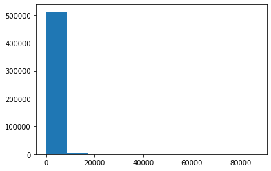

```python
plt.hist(df['duration_sec']);
```

This is extremely right skewed, which points to possibly the presence of outliers. Let's draw a boxplot of the `duration_sec` to verify that.

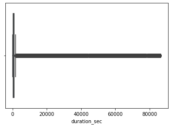

```python
sns.boxplot(df['duration_sec']);
```

Wow! There are many outliers which is making the boxplot look all weird, let's create an updated version of the dataframe with reasonable durations.

```python
df['duration_sec'].describe()
```

```
count    519700.000000
mean       1099.009521
std        3444.146451
min          61.000000
25%         382.000000
50%         596.000000
75%         938.000000
max       86369.000000
Name: duration_sec, dtype: float64
```

From here we can see that that $75\%$ of our data is less than 1000 secs. We see that the max is 86369 seconds which is almost a whole day! Probably the user forgot to log off, or the bike was stolen. We need to realistically look at the data, so let's assume a cutoff of 3600 secs (maximum ride duration of an hour).

```python
df = df[df['duration_sec'] <= 3600]
```

```python
#View the updated dataframe:
df.describe()
```

|  | duration_sec | start_station_id | end_station_id | bike_id |
| --- | --- | --- | --- | --- |
| count | 503519.000000 | 503519.000000 | 503519.000000 | 503519.000000 |
| mean | 711.680320 | 95.000705 | 92.050242 | 1675.660619 |
| std | 498.596522 | 85.676415 | 84.437401 | 971.720043 |
| min | 61.000000 | 3.000000 | 3.000000 | 10.000000 |
| 25% | 376.000000 | 24.000000 | 23.000000 | 790.000000 |
| 50% | 581.000000 | 67.000000 | 66.000000 | 1733.000000 |
| 75% | 891.000000 | 138.000000 | 134.000000 | 2524.000000 |
| max | 3600.000000 | 340.000000 | 340.000000 | 3733.000000 |

We still have around $500,000$ records but we have gotten rid of many outliers! let's plot the distribution again, properly this time.

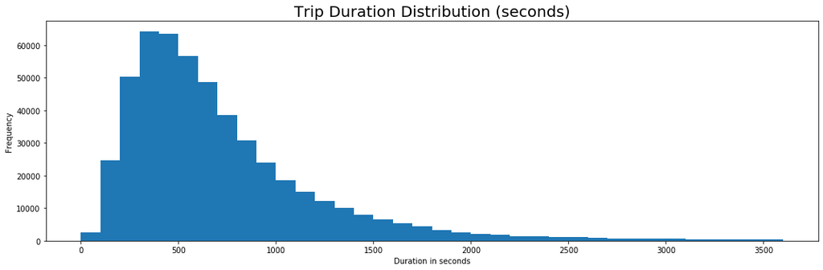

```python
plt.figure(figsize=(15,5))
bins = np.arange(0, df['duration_sec'].max() + 100 , 100)
plt.hist(df['duration_sec'] , bins = bins)
#sns.distplot(df['duration_sec'],bins=bins,kde=False)
plt.title('Trip Duration Distribution (seconds)',fontsize=20)
plt.xlabel('Duration in seconds');
plt.ylabel('Frequency')
plt.tight_layout()
```

From this chart, we can see that the distribution is right-skewed with most of the data between the 350-850 seconds (6-14 minutes) range.

Now let's move on to another variable, we'll use `day_name` to look at the number of rides per each day of the week.

```python
df['day_name'].value_counts()
```

```
Wednesday    86114
Tuesday      86101
Thursday     83288
Monday       79589
Friday       78880
Saturday     47484
Sunday       42063
Name: day_name, dtype: int64
```

We can see that Wednesday and Tuesday have the two highest values, with Wednesday being higher by only $13$ rides. Let's visualize that using a countplot.

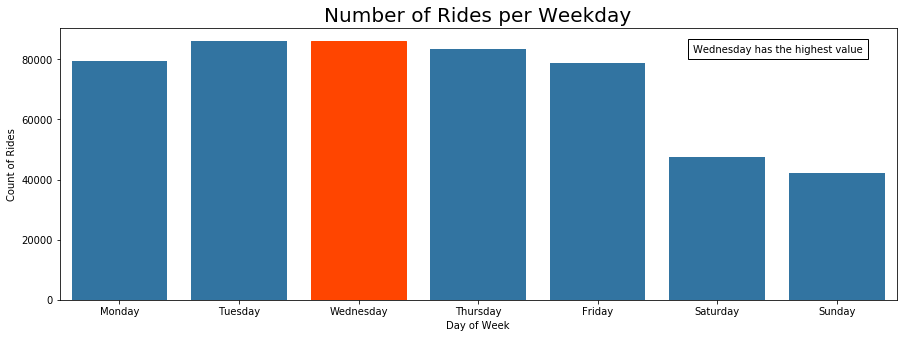

```python
plt.figure(figsize=(15,5))
ax = plt.axis()
base_color= sns.color_palette()[0]
week_order = ['Monday','Tuesday','Wednesday','Thursday','Friday','Saturday','Sunday']
ax = sns.countplot(df['day_name'],order=week_order,color=base_color)
#set color of Wednesday to distinct it from the rest of the days (as it's the maximum)
for patch in ax.patches:
    if patch.get_height() == df['day_name'].value_counts().max():
        patch.set_color('orangered')
plt.title('Number of Rides per Weekday',fontsize=20)
plt.xlabel('Day of Week')
plt.ylabel('Count of Rides');
plt.text(.96,.94,"Wednesday has the highest value", bbox={'facecolor':'w','pad':5},
         ha="right", va="top", transform=plt.gca().transAxes );
```

Continuing on with the theme of $Time$, let's explore the number of rides per `month`. We'll add a column for `month` name to our dataframe.

```python
#Add month name column similar to day_name
df['month'] = df['start_time'].dt.month_name()

#Check values of that column
df['month'].value_counts()
```

```
October      106131
September     95013
November      93593
December      84721
August        79961
July          41524
June           2576
Name: month, dtype: int64
```

Clearly, `October` has the highest number of rides in our dataset! Let's visualize that with seaborn as well.

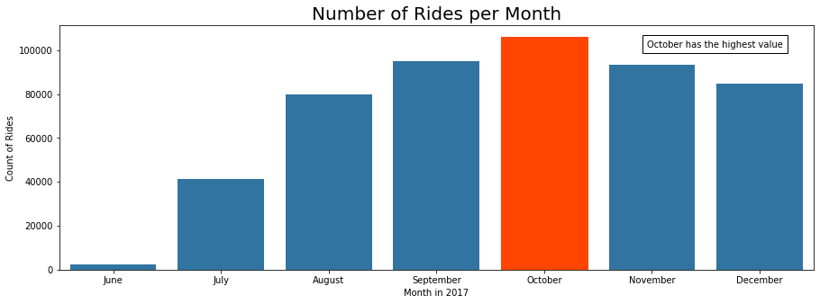

```python
plt.figure(figsize=(15,5))
ax = plt.axis()
base_color= sns.color_palette()[0]
year_order = ['June','July','August','September','October','November','December']
ax = sns.countplot(df['month'],order=year_order,color=base_color)
#set color of October to distinct it from the rest of the days (as it's the maximum)
for patch in ax.patches:
    if patch.get_height() == df['month'].value_counts().max():
        patch.set_color('orangered')
plt.title('Number of Rides per Month',fontsize=20)
plt.xlabel('Month in 2017')
plt.ylabel('Count of Rides');
plt.text(.96,.94,"October has the highest value", bbox={'facecolor':'w','pad':5},
         ha="right", va="top", transform=plt.gca().transAxes );
```

Also note that we have very few data points for `June`, perhaps this has to do with the starting point of our dataset which was the 28th of June as we found out here.

Now let's zoom in a little bit and check the distribution for the number of rides per hour. we'll create an `hour` column as well!

```python
#Create the column
df['hour'] = df['start_time'].dt.hour

#view hour values
df['hour'].value_counts()
```

```
17    59056
8     56608
18    45307
9     44523
16    40117
15    27042
7     26480
19    26070
12    25863
13    25674
10    23896
14    23320
11    22680
20    16325
21    11720
6      8764
22     7748
23     4727
0      2491
5      2075
1      1285
2       794
4       609
3       345
Name: hour, dtype: int64
```

We can see that the most number of hours is at 17:00 which is 5 p.m. Now let's plot that to see what the data might show us.

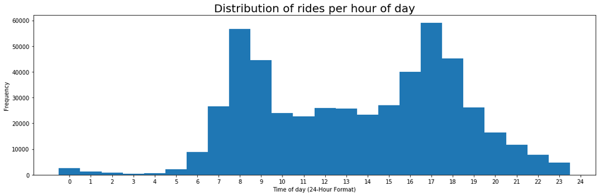

```python
plt.figure(figsize=(15,5))
#make 25 bins (24 hours + 1)
bins = np.arange(0, 24+1, 1)
plt.hist(df['hour'],bins=bins)
plt.title('Distribution of rides per hour of day',fontsize=20)
plt.xlabel('Time of day (24-Hour Format)')
plt.ylabel('Frequency')
plt.xticks(bins+0.5,bins) #center label with bar
plt.tight_layout();
```

We can see that this is a **Bi-Modal** distribution with 2 peaks at 8 a.m. (8:00) and 5 p.m. (17:00).

Finishing off our time-related analyses with a timeseries plot to show the number of rides per day through our whole dataset to observe trends in growth. We'll create a `date` column containing the date of each day so we can group by these values.

```python
#create date column.
df['date'] = df['start_time'].dt.date

#check the values of the created column.
df['date'].value_counts()
```

```
2017-10-26    4609
2017-11-07    4470
2017-11-14    4430
2017-10-24    4401
2017-12-06    4347
              ...
2017-07-03     556
2017-07-04     482
2017-07-02     453
2017-07-09     394
2017-07-01     384
Name: date, Length: 187, dtype: int64
```

We can see that our highest number of rides per day happend on the 26th of October, 2017. Let's plot the timeseries plot now:

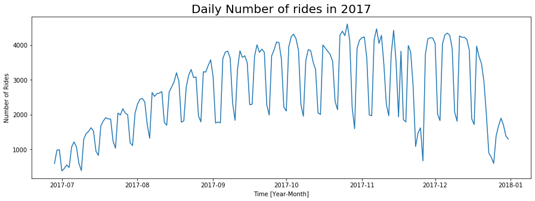

```python
plt.figure(figsize=(15,5))
df.groupby('date')['duration_sec'].count().plot()
plt.title('Daily Number of rides in 2017',fontsize=20)
plt.xlabel('Time [Year-Month]')
plt.ylabel('Number of Rides');
```

From this chart, we can clearly see that there was an upward trend starting with the beginning of the 2nd half of 2017 and continuing until it plateaus and then drops near the end of 2017! However, this chart has a lot of noise, probably because of the low ride counts on weekends, so perhaps we can smooth it out to better observe the trend by plotting the `monthly` number of rides vs. time instead of daily number.

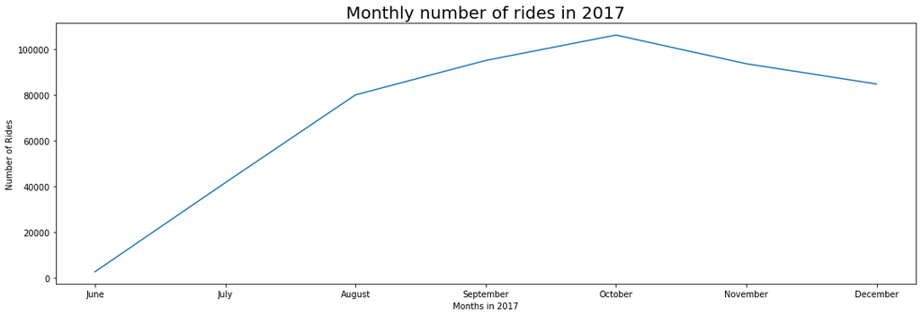

```python
# remember the year_order list we had before, we'll use it to reindex the counts to ensure a coherent x-axis timewise.
plt.figure(figsize=(15,5))
df.groupby('month')['duration_sec'].count().reindex(year_order).plot()
plt.tight_layout()
plt.title('Monthly number of rides in 2017',fontsize=20)
plt.xlabel('Months in 2017')
plt.ylabel('Number of Rides');
```

Our observations were correct, the line clearly shows an upward trend at the beginning of the 2nd half on 2017, with a decline towards the end of the year, perhaps it can be explained due to the cold weather.

Now let's see the number of rides per origin location, i.e. `start_station_name`.

```python
df.start_station_name.value_counts()
```

```
San Francisco Ferry Building (Harry Bridges Plaza)           14154
The Embarcadero at Sansome St                                12613
San Francisco Caltrain (Townsend St at 4th St)               12420
San Francisco Caltrain Station 2  (Townsend St at 4th St)    11966
Market St at 10th St                                         11736
                                                             ...
Pierce Ave at Market St                                         11
Harmon St at Adeline St                                          6
Empire St at 1st St                                              5
Jackson St at 11th St                                            2
Ellsworth St at Russell St                                       1
Name: start_station_name, Length: 272, dtype: int64
```

we have 272 origin stations, let's just look at the top 20 locations.

```python
df.start_station_name.value_counts().head(20)
```

```
San Francisco Ferry Building (Harry Bridges Plaza)           14154
The Embarcadero at Sansome St                                12613
San Francisco Caltrain (Townsend St at 4th St)               12420
San Francisco Caltrain Station 2  (Townsend St at 4th St)    11966
Market St at 10th St                                         11736
Montgomery St BART Station (Market St at 2nd St)             11031
Berry St at 4th St                                           10784
Howard St at Beale St                                         9825
Powell St BART Station (Market St at 4th St)                  9582
Steuart St at Market St                                       9095
Powell St BART Station (Market St at 5th St)                  7635
Embarcadero BART Station (Beale St at Market St)              7424
2nd St at Townsend St - Coming Soon                           6519
3rd St at Townsend St                                         6319
Townsend St at 7th St                                         6157
The Embarcadero at Steuart St                                 5848
2nd St at S Park St                                           5724
Howard St at 2nd St                                           5642
19th Street BART Station                                      5464
Union Square (Powell St at Post St)                           5220
Name: start_station_name, dtype: int64
```

Okay, looks good! The values at the top are probably located at busy districts or tourist attractions! let's plot a horizontal barplot to show the different counts for rides per origin.

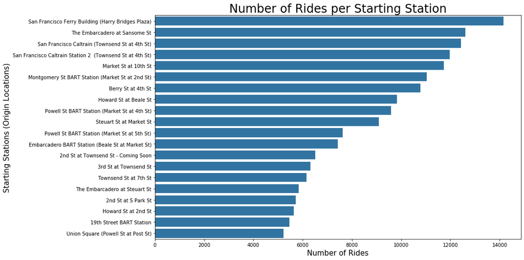

```python
plt.figure(figsize=(15,7.5))
origins = df.start_station_name.value_counts().head(20)
#remember our basecolor to produce a good interpretable output
sns.barplot(y=origins.index.values,x=origins.values,color=base_color)
plt.xlabel('Number of Rides',fontsize=15)
plt.ylabel('Starting Stations (Origin Locations)',fontsize=15)
plt.title('Number of Rides per Starting Station',fontsize=24)
plt.tight_layout();
```

Finally, let's check the percentages of the `user_type` values to see the proportion of `subscriber` vs `customer` users.

```python
df['user_type'].value_counts()
```

```
Subscriber    406856
Customer       96663
Name: user_type, dtype: int64
```

We can see that there are clearly many more subscribers than there are customers! Let's plot that with a pie chart.

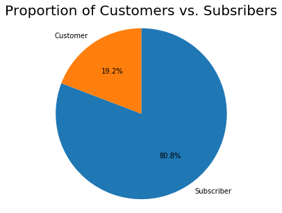

```python
plt.figure(figsize=(15,5))
df.user_type.value_counts().plot(kind='pie',autopct='%1.1f%%',startangle=90,counterclock=False)
plt.ylabel('')
plt.title('Proportion of Customers vs. Subsribers',fontsize=20)
plt.axis('square');
```

This pie chart clearly shows that almost $81\%$ of our dataset are `Subscriber`s while only $20\%$ of the dataset are `Customer`s.

### Discuss the distribution(s) of your variable(s) of interest. Were there any unusual points? Did you need to perform any transformations?

> - `duration_sec` had so many outliers that unrightfully skewed our data. We had to get rid of them.
> - The number of rides per `day_name` column showed that a less number of rides was taken on the weekends which was counterintuitive.
> - There was a clear upward trend when grouping the dataframe by the number of rides taking each unit of time, the trend then declines by the end of the year.

### Of the features you investigated, were there any unusual distributions? Did you perform any operations on the data to tidy, adjust, or change the form of the data? If so, why did you do this?

> - From `duration_sec`, we saw that the distribution is right-skewed with most of the data within the 350-850 seconds (6-14 minutes) range.
> - `hour` distribution proved to be bi-modal with peaks at different times of the same day.
> - We had to make many transformations pretaining to the datetime objects and we based many of our analyses and visualizations on these engineered features.

## Bivariate Exploration

First, We're interested in the `user_type` to produce variations of our previous explorations.

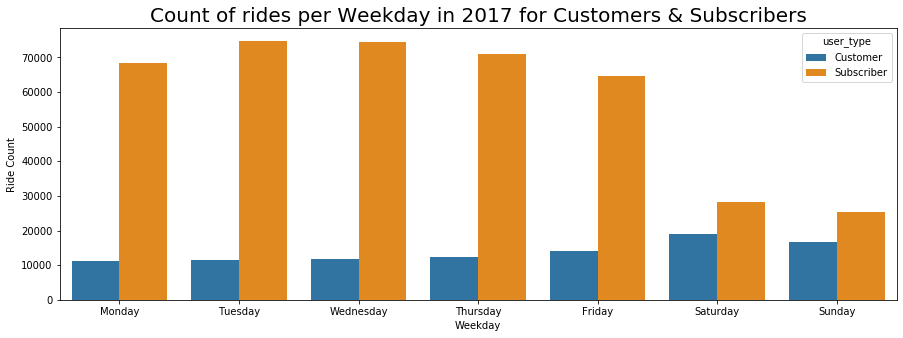

```python
plt.figure(figsize=(15,5))
sns.countplot(df['day_name'],palette=[base_color,'darkorange'],hue=df['user_type'],order=week_order)
plt.title('Count of rides per Weekday in 2017 for Customers & Subscribers',fontsize=20)
plt.ylabel('Ride Count',fontsize=10)
plt.xlabel('Weekday',fontsize=10);
```

We can see that the usage for subscribers is always higher than customers, and that the `customer` trend is actually different from the overall dataset trend. This is because the `Customer` values only present about 20% of the values as we found before.

So how did our dataset grow ith the passing of time? Who subscribed more with the official re-launching as `Ford GoBike` on June 28, 2017 (The Beginning point for our dataset).

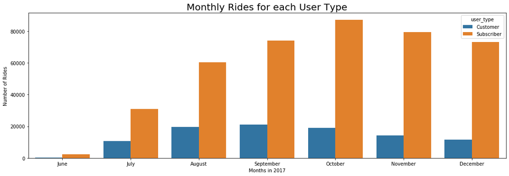

```python
plt.figure(figsize=(15,5))
sns.countplot(x='month',hue='user_type',data=df,order=year_order)
plt.tight_layout()
plt.title('Monthly Rides for each User Type',fontsize=20)
plt.xlabel('Months in 2017')
plt.ylabel('Number of Rides');
```

We can clearly see that there was an explosion of subscribers as opposed to regular customers in the beginning of the launch.

As we have more subscribers, does that mean that the average duration for subscriber rides is larger that the average duration for customer rides? We cannot possibly determine that without more analysis. Let's start with a boxplot to see the different data ranges.

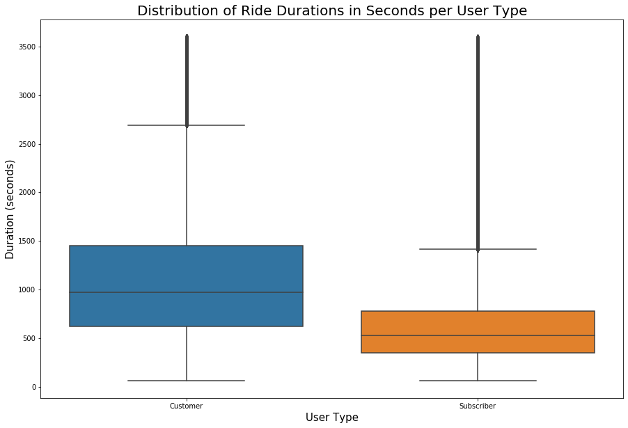

```python
plt.figure(figsize=(15,10))
sns.boxplot(x='user_type',y='duration_sec',data=df)
plt.title('Distribution of Ride Durations in Seconds per User Type',fontsize=20)
plt.ylabel('Duration (seconds)',fontsize=15)
plt.xlabel('User Type',fontsize=15);
```

We can see that the contorary to our initial hypothesis, the average ride duration for normal Customers is actually around 2 times bigger than the average ride duration for Subscribers!

This may indicate that `subscriber`s usually take rides for predefined destinations, e.g. commuting to work. On the other hand, normal customers don't have a specific destination as all of them are casual riders and probably lots of them are tourists. If this were true, we should find the standard deviation for the customer `user_type` to be bigger than the standard deviation for the subscriber `user_type`

First, we'll use a bar plot to check the mean of both of them.

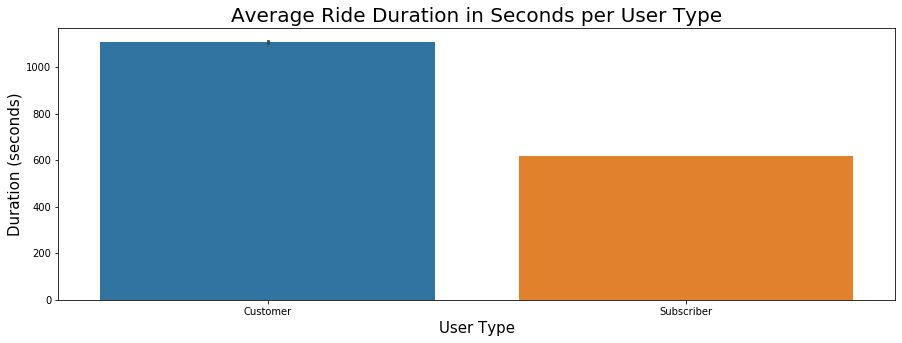

```python
#First, check the mean per user_type
plt.figure(figsize=(15,5))
sns.barplot(x='user_type',y='duration_sec',data=df)
plt.title('Average Ride Duration in Seconds per User Type',fontsize=20)
plt.ylabel('Duration (seconds)',fontsize=15)
plt.xlabel('User Type',fontsize=15);
```

And now to check the standard deviation, we'll use the `estimator` parameter.

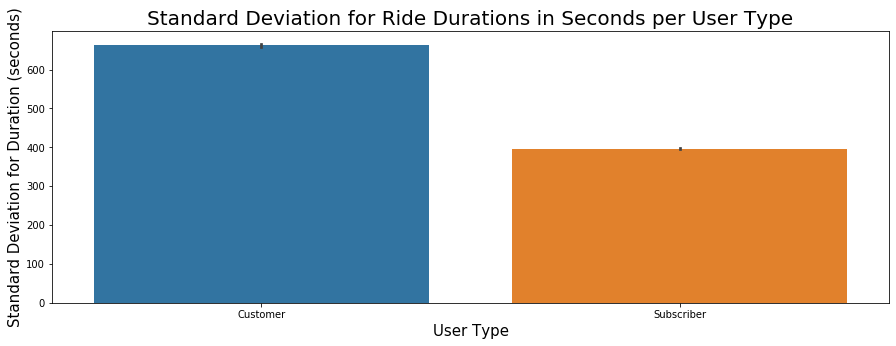

```python
plt.figure(figsize=(15,5))
sns.barplot(x='user_type',y='duration_sec',data=df,estimator=np.std)
plt.title('Standard Deviation for Ride Durations in Seconds per User Type',fontsize=20)
plt.ylabel('Standard Deviation for Duration (seconds)',fontsize=15)
plt.xlabel('User Type',fontsize=15);
```

And yes, the standard deviation for customer `user_type` is indeed higher than that of subscriber `user_type`.

Now for one final plot for `user_type` hues, we'll check the usage statistics for the top 20 `start_station_names`.

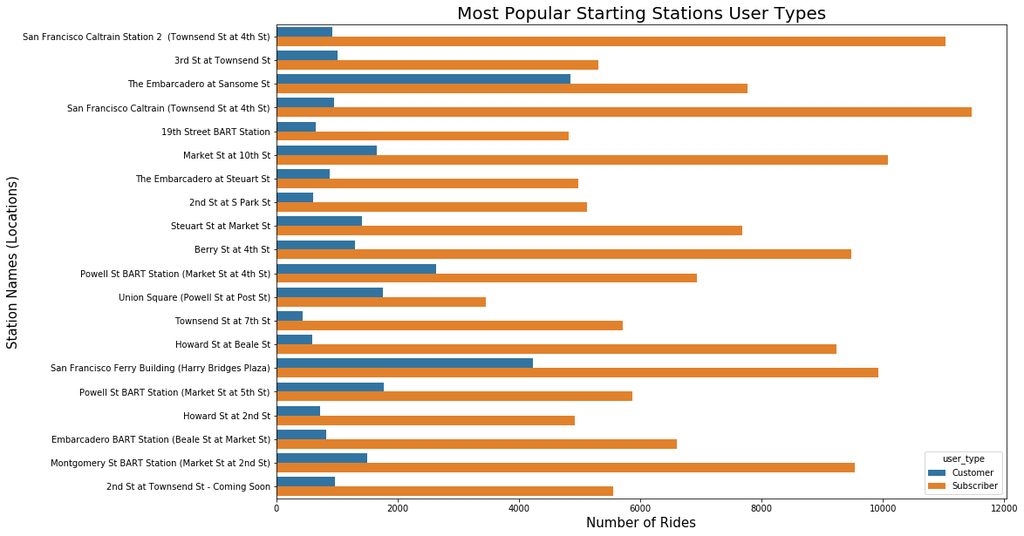

```python
plt.figure(figsize=(15,10))
sns.countplot(y = df[df.start_station_name.isin(origins.index.values)]['start_station_name'],hue=df['user_type'])
plt.title('Most Popular Starting Stations User Types',fontsize=20)
plt.xlabel('Number of Rides',fontsize=15)
plt.ylabel('Station Names (Locations)',fontsize=15);
```

Additionally, we can plot the average duration per weekday and see if it will follow the total number of rides pattern.

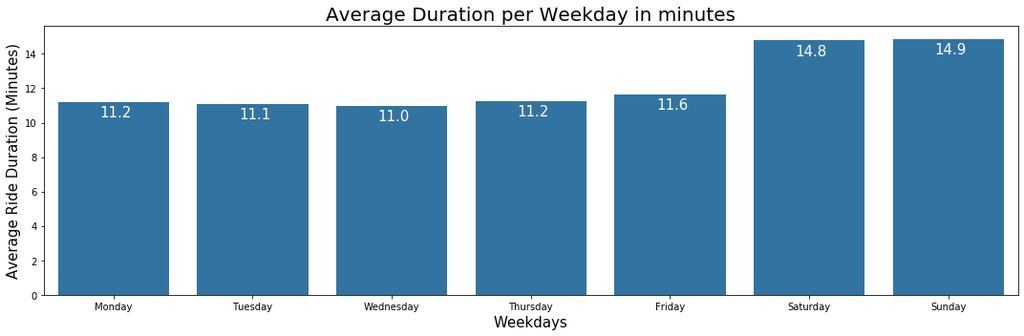

```python
plt.figure(figsize=(15,5))
mean_dur = df.groupby('day_name')['duration_sec'].mean().reindex(week_order)/60
ax = sns.barplot(mean_dur.index.values,mean_dur.values,color=base_color)
for i, v in enumerate(mean_dur.values):
    #print(i,v)
    ax.text(i-0.1,v-0.85,s='{:.1f}'.format(v),color='white',fontsize=15)
plt.title('Average Duration per Weekday in minutes',fontsize=20)
plt.xlabel('Weekdays',fontsize=15)
plt.ylabel('Average Ride Duration (Minutes)',fontsize=15)
plt.tight_layout();
```

Wow, it's almost the opposite of the trend we expected! The average duration during the weekend is actually higher despite sunday and saturday having the fewest number of rides. Also, Wednesday, which had the highest number of rides, has the minimum average duration for rides in minutes!

### Talk about some of the relationships you observed in this part of the investigation. How did the feature(s) of interest vary with other features in the dataset?

> We have found many interesting statistics pretaining to usage statistics by `customer` vs `subsriber` user types. They seem to be the main category affecting our analyses. Due to the proportions, there are trends in `customer` data that weren't very obvious because of the dominating `subscriber` proportion.

### Did you observe any interesting relationships between the other features (not the main feature(s) of interest)?

> We did observe lots of interesting relationships. But the main one we'll mention is the average duration of rides when plotted against weekdays. Weekends (Saturday and Sunday) have much higher `ride_duration` averages in minutes!

## Multivariate Exploration

> We'll see if we can strengthen our findings by introducing three or more variables to our charts.

First, we'll plot a scatter plot between most popular origin stations i.e. `start_station_name` , the duration for each ride out of that station i.e. `duration_sec` , and then we'll split them even further by `user_type`!

```python
#Create the mini dataframe with only the most popular stations
station_df = df[df['start_station_name'].isin(origins.index.values)]

station_df
```

|  | duration_sec | start_time | end_time | start_station_id | start_station_name | end_station_id | end_station_name | bike_id | user_type | day_name | month | hour | date |
| --- | --- | --- | --- | --- | --- | --- | --- | --- | --- | --- | --- | --- | --- |
| 12 | 2183 | 2017-12-31 23:52:55.581 | 2018-01-01 00:29:18.743 | 67 | San Francisco Caltrain Station 2 (Townsend St... | 24 | Spear St at Folsom St | 2311 | Subscriber | Sunday | December | 23 | 2017-12-31 |
| 13 | 2170 | 2017-12-31 23:52:55.937 | 2018-01-01 00:29:06.924 | 67 | San Francisco Caltrain Station 2 (Townsend St... | 24 | Spear St at Folsom St | 3717 | Subscriber | Sunday | December | 23 | 2017-12-31 |
| 14 | 2697 | 2017-12-31 23:35:23.222 | 2018-01-01 00:20:20.813 | 66 | 3rd St at Townsend St | 23 | The Embarcadero at Steuart St | 3452 | Customer | Sunday | December | 23 | 2017-12-31 |
| 23 | 1165 | 2017-12-31 23:35:55.543 | 2017-12-31 23:55:21.220 | 66 | 3rd St at Townsend St | 23 | The Embarcadero at Steuart St | 3671 | Customer | Sunday | December | 23 | 2017-12-31 |
| 24 | 1149 | 2017-12-31 23:36:03.555 | 2017-12-31 23:55:13.465 | 66 | 3rd St at Townsend St | 23 | The Embarcadero at Steuart St | 3375 | Customer | Sunday | December | 23 | 2017-12-31 |
| ... | ... | ... | ... | ... | ... | ... | ... | ... | ... | ... | ... | ... | ... |
| 519695 | 435 | 2017-06-28 10:00:54.528 | 2017-06-28 10:08:10.438 | 81 | Berry St at 4th St | 45 | 5th St at Howard St | 400 | Subscriber | Wednesday | June | 10 | 2017-06-28 |
| 519696 | 431 | 2017-06-28 09:56:39.631 | 2017-06-28 10:03:51.090 | 66 | 3rd St at Townsend St | 321 | 5th at Folsom | 316 | Subscriber | Wednesday | June | 9 | 2017-06-28 |
| 519697 | 424 | 2017-06-28 09:47:36.347 | 2017-06-28 09:54:41.187 | 21 | Montgomery St BART Station (Market St at 2nd St) | 48 | 2nd St at S Park St | 240 | Subscriber | Wednesday | June | 9 | 2017-06-28 |
| 519698 | 366 | 2017-06-28 09:47:41.664 | 2017-06-28 09:53:47.715 | 58 | Market St at 10th St | 59 | S Van Ness Ave at Market St | 669 | Subscriber | Wednesday | June | 9 | 2017-06-28 |
| 519699 | 188 | 2017-06-28 09:49:46.377 | 2017-06-28 09:52:55.338 | 25 | Howard St at 2nd St | 48 | 2nd St at S Park St | 117 | Subscriber | Wednesday | June | 9 | 2017-06-28 |

175158 rows × 13 columns

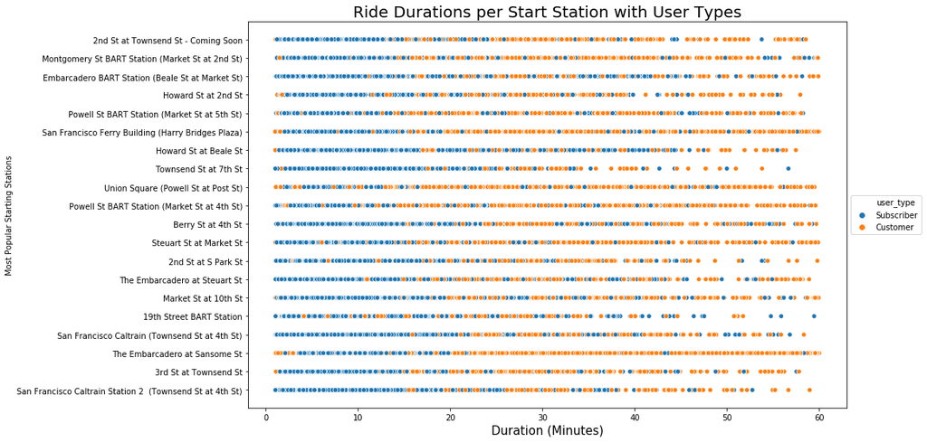

```python
#plot the scatter plot
plt.figure(figsize=(15,7.5))
sns.scatterplot(y=station_df['start_station_name'],x=station_df['duration_sec']/60,hue=station_df['user_type'])
plt.tight_layout()
plt.title('Ride Durations per Start Station with User Types',fontsize=20)
plt.xlabel('Duration (Minutes)',fontsize=15)
plt.ylabel('Most Popular Starting Stations')
plt.legend(loc='center left', bbox_to_anchor=(1, 0.5));
```

From that plot we can confirm that `Subscriber` types have on average less ride durations than `Customer` types no matter which station they start from.

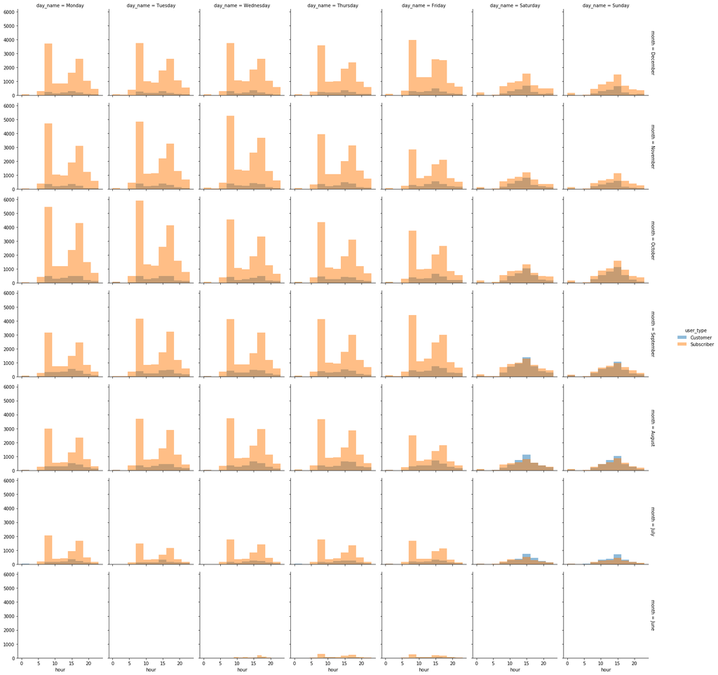

```python
g = sns.FacetGrid(data=df,col='day_name',row='month',hue='user_type',margin_titles=True,col_order=week_order)
g.map(plt.hist,'hour',alpha=0.5)
g.add_legend()
```

From here we can see that the distribution of hourly usage by user type have some faint similarities over different days. the Bi-modality is very obvious in subscriber `user_id` during working days. However, on the weekends, both subsriber and customer types follow a left-skewed normal distribution.

## Conclusion

### Some Observations:

> Our first finding illustrated how subscribers do in fact use the bikes for shorter rides no matter what station they originate from!

### Interesting interactions between features:

> We decided to check if this is because subscriber users probably use the bikes to commute, if they did, we expect to see bimodal distributions for them no matter the month of the year, or the day of the working week.

> We found that to be true, and the only exception is on weekend where both user types are pretty similar in their usage.

# **Readme and presentation files are separately attached.**